# MLProj

Pradeep Gurav

23/05/2020

## Executive Summary

The goal of this project is to predict the manner in which subjects did the exercise. The data for this project come from this source: http://groupware.les.inf.puc-rio.br/har. I have used RandomForest method to build the model. This report describes:  
* how the model is built  
* use of cross validation  
* an estimate of expected out of sample error  
* Predictied values for the Testdata provided

## Getting and cleaning the Data

```r
set.seed(123)

train.url <-
        "https://d396qusza40orc.cloudfront.net/predmachlearn/pml-training.csv"
test.url <-
        "https://d396qusza40orc.cloudfront.net/predmachlearn/pml-testing.csv"

path <- paste(getwd(),"/", sep="")
train.file <- file.path(path, "machine-train-data.csv")
test.file <- file.path(path, "machine-test-data.csv")
if (!file.exists(train.file)) {
        download.file(train.url, destfile=train.file)
}
if (!file.exists(test.file)) {
        download.file(test.url, destfile=test.file)
}

train.data.raw <- read.csv(train.file, na.strings=c("NA","#DIV/0!",""))
test.data.raw <- read.csv(test.file, na.strings=c("NA","#DIV/0!",""))

## Remove irrelevant colums

# Drop the first 7 columns as they're not relevant for predicting.
train_data <- train.data.raw[,8:length(colnames(train.data.raw))]
test_data <- test.data.raw[,8:length(colnames(test.data.raw))]

# Drop colums with NAs
train_data <- train_data[, colSums(is.na(train_data)) == 0]
test_data <- test_data[, colSums(is.na(test_data)) == 0]

# Check for near zero variance predictors and drop them if necessary
nzv <- nearZeroVar(train_data,saveMetrics=TRUE)
zero.var.ind <- sum(nzv$nzv)

if ((zero.var.ind>0)) {
        train_data <- train_data[,nzv$nzv==FALSE]
}

# Check for near zero variance predictors and drop them if necessary
```

## Split the data for cross validation

The training data is divided into two sets. This first is a training set with 70% of the data which is used to train the model. The second is a cross validation set used to assess model performance.

```r
in.training <- createDataPartition(train_data$classe, p=0.70, list=F)
train.data.final <- train_data[in.training, ]
crossvalidata <- train_data[-in.training, ]
```

## Model Development

We will use random forest as the model as implemented in the randomForest package.

# Why we will use RandomForest method to build a model

Because  
* it automatically selects important variables and  
* is robust to correlated covariates & outliers in general  
* 5-fold cross validation is used in the algorithm.  
* averages multiple deep decision trees

```r
control.parms <- trainControl(method="cv", 5)
rf.model <- train(classe ~ ., data=train.data.final, method="rf",
                 trControl=control.parms, ntree=100)

# Training set accuracy
#ptraining <- predict(rf.model, train.data.final)
#print(confusionMatrix(ptraining, train.data.final$classe))
```

## Cross Validation using the Validation dataset (Out of Sample)

Let us now see how the model performs on the cross validation set that we held out from training.

```r
rf.predict <- predict(rf.model, crossvalidata)
print(confusionMatrix(crossvalidata$classe, rf.predict))
```

```
## Confusion Matrix and Statistics
##
##           Reference
## Prediction    A    B    C    D    E
##          A 1673    1    0    0    0
##          B    5 1127    7    0    0
##          C    0    5 1020    1    0
##          D    0    0   10  954    0
##          E    0    0    5    6 1071
##
## Overall Statistics
##
##                Accuracy : 0.9932
##                  95% CI : (0.9908, 0.9951)
##     No Information Rate : 0.2851
##     P-Value [Acc > NIR] : < 2.2e-16
##
##                   Kappa : 0.9914
##
##  Mcnemar's Test P-Value : NA
##
## Statistics by Class:
##
##                      Class: A Class: B Class: C Class: D Class: E
## Sensitivity            0.9970   0.9947   0.9789   0.9927   1.0000
## Specificity            0.9998   0.9975   0.9988   0.9980   0.9977
## Pos Pred Value         0.9994   0.9895   0.9942   0.9896   0.9898
## Neg Pred Value         0.9988   0.9987   0.9955   0.9986   1.0000
## Prevalence             0.2851   0.1925   0.1771   0.1633   0.1820
## Detection Rate         0.2843   0.1915   0.1733   0.1621   0.1820
## Detection Prevalence   0.2845   0.1935   0.1743   0.1638   0.1839
## Balanced Accuracy      0.9984   0.9961   0.9888   0.9953   0.9989
```

The cross validation accuracy is 99.32% and the out-of-sample error is therefore 0.68% so the model performs rather good.

# Out of sample error with the model is .68%

## Test set prediction

The prediction of the algorithm for the test set is:

```r
results <- predict(rf.model,
                   test_data[, -length(names(test_data))])
results
```

```
##  [1] B A B A A E D B A A B C B A E E A B B B
## Levels: A B C D E
```

We then save the output to files according to instructions and post it to the submission page.

## Reference

Velloso, E.; Bulling, A.; Gellersen, H.; Ugulino, W.; Fuks, H. Qualitative Activity Recognition of Weight Lifting Exercises. Proceedings of 4th International Conference in Cooperation with SIGCHI (Augmented Human ’13). Stuttgart, Germany: ACM SIGCHI, 2013

## Annexure Graph

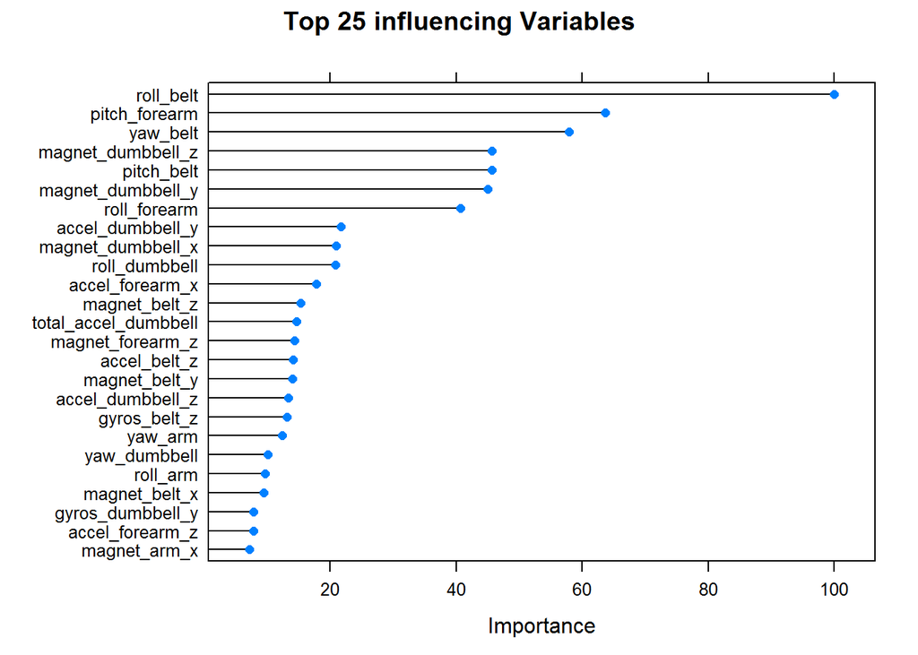

```r
ImpObj <- varImp(rf.model)
plot(ImpObj, main = "Top 25 influencing Variables", top = 25)
```